# Text Analysis Replication

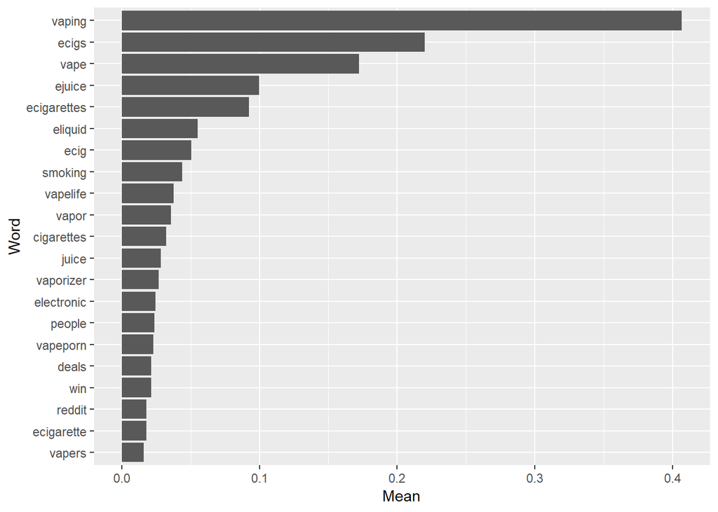

```r
m <- ggplot(data = doctfiltDFM[1:21, ], aes(x = reorder(word, freq), y = freq)) +
    xlab("Word") + ylab("Mean") + geom_bar(stat = "identity") + coord_flip()
m  #plot of the mean#
```

```r
findFreqTerms(doctfilt3DTM, lowfreq = 0, highfreq = Inf)
```

```
##  [1] "ecigs"         "ecigarette"    "people"        "vape"
##  [5] "electronic"    "ecig"          "deals"         "vapor"
##  [9] "good"          "vapelife"      "vaping"        "cigarettes"
## [13] "reddit"        "win"           "eliquid"       "smoke"
## [17] "ejuice"        "ecigarettes"   "vapejuice"     "vaporizer"
## [21] "smoking"       "vegas"         "juice"         "trees"
## [25] "prices"        "quit"          "vapecommunity" "vapers"
## [29] "vapeporn"      "vapours"
```

```r
# Correlation - we'll look at the correlation between the most appeared
# terms#
findAssocs(doctfilt3DTM, terms = c("vaping", "ecigs"), corlimit = 0.1)
```

```
## $vaping
##          vape      vapelife         trees vapecommunity      vapeporn
##          0.13          0.13          0.13          0.12          0.12
##
## $ecigs
##     reddit    vapours     prices ecigarette        win
##       0.24       0.19       0.18       0.11       0.10
```

```r
findAssocs(doctfilt3DTM, terms = c("vaping", "quit"), corlimit = 0.1)  #shows that there was a stronger correlation between the term quit and smoking and could be assumed that these terms had a frequent co-occurence#
```

```
## $vaping
##          vape      vapelife         trees         ecigs vapecommunity
##          0.13          0.13          0.13          0.12          0.12
##      vapeporn
##          0.12
##
## $quit
##     smoking ecigarettes
##        0.24        0.11
```

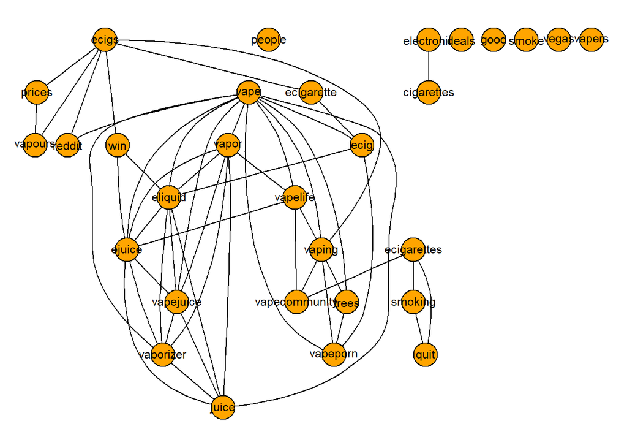

```r
attrs <- list(node = list(fillcolor = "orange", fontsize = "50"), edge = list(),
    graph = list())
plot(doctfilt3DTM, terms = findFreqTerms(doctfilt3DTM, lowfreq = 1000), attrs = attrs,
    corThreshold = 0.1)
```

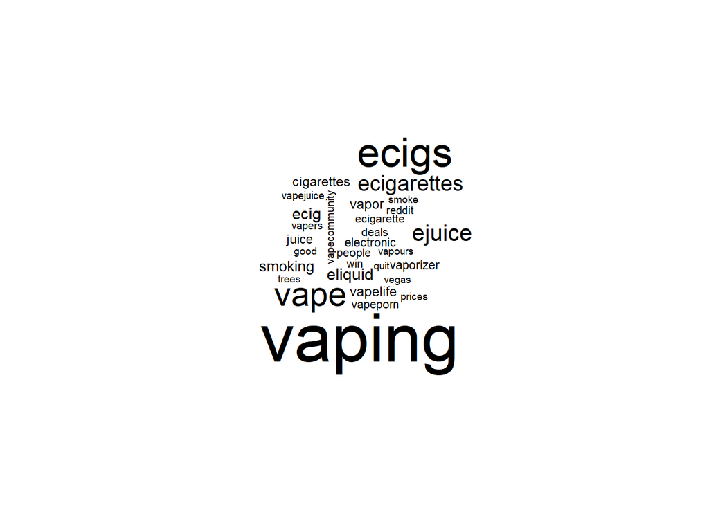

```r
# A plot of correlation among terms that appear in atleast 1000 tweets with
# a correlation of at least 0.10)
set.seed(1)
wordcloud(doctfiltDF$word, doctfiltDF$freq, min.freq = 500)  #Wordcloud showing the words in order of frequency#
```

## Summary

In this analysis, we clean the data, filter out the least frequent terms to ascertain the most used terms and their co-occurence through correlation. We can see that the strongest co-occurence appears to be that of the term vape. For example, looking at its co-occurence with reddit, we can assume that there were some promotional interactions where the reditt links were shared in context of vape (and similarly in context of ecigs).

The analysis in the actual paper goes on to determining the topic models and determin the exact number of tweets that fell in each topics. For the same, expectation maximization (EM) clustering in SAS was used. However, this analysis could only carry out determining the term frequencies and instead found out the average use of the terms and plotted their co-occurences that points indirectly at the kind of conversation that would have occured through tweets. Thus, looking at the co-occurence plot, we can assume that majority of conversations were of people sharing their experiences of using vape or ecigs (vape - vapeporn, vaping - vapecommunity, etc.), there were several promotional conversations that promoted ‘winning’ ecig or had interactions about prices and lastly, there were conversations that motivated quitting smoking and even ecigarettes.

## References

Lazard, A. J., Saffer, A. J., Wilcox, G. B., Chung, A. D., Mackert, M. S., & Bernhardt, J. M. (2016). E-cigarette social media messages: a text mining analysis of marketing and consumer conversations on Twitter. JMIR public health and surveillance, 2(2), e171.